# Code from paper ‘Operative versus non-operative management of rib fractures in flail chest after cardiopulmonary resuscitation’, Dorn et al.

Simone Oberhaensli, Interfaculty Bioinformatics Unit, University of Bern

2021-08-17

## Introduction

For all analyses a significance threshold of p < 0.05 is applied.

## Analyses with both groups as one cohort

In the following section we perform some comparisons between the group that underwent stabilization surgery (Sx) and the group that was treated conservatively (noSx).

### Primary endpoint: time spent on respirator

Is there a significant difference in the number of days that patients spent on the respirator between the groups Sx and noSx?  
The cohort includes 21 individuals (deceased patients excluded).

```
## Data are approximatelly normally distributed
```

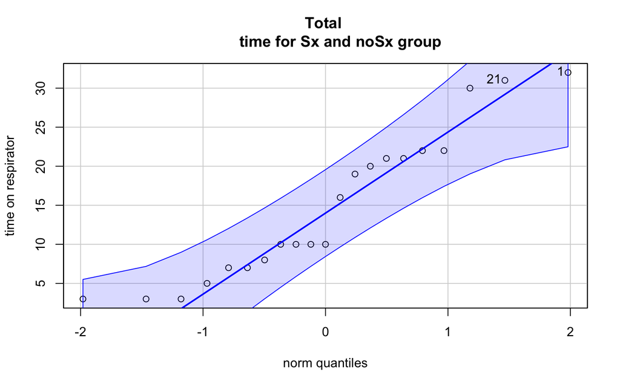

```
## [1]  1 21
```

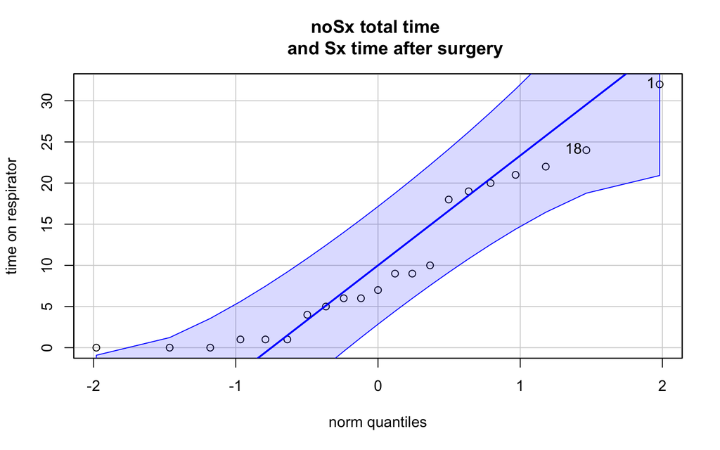

```
## [1]  1 18
```

```
## There is no significant difference of total time spent on respirator between
##     the Sx and noSx group
```

```
##
##  Welch Two Sample t-test
##
## data:  d.nSx$Respirator.time and d.Sx$Respirator.time
## t = 0.86164, df = 15.93, p-value = 0.4017
## alternative hypothesis: true difference in means is not equal to 0
## 95 percent confidence interval:
##  -5.282743 12.513512
## sample estimates:
## mean of x mean of y
##  17.00000  13.38462
```

```
## There is a significant difference if the time on the respirator after
##     surgery for the Sx group is compared to the total time of the noSx group
```

```
##
##  Welch Two Sample t-test
##
## data:  d.nSx$newtime and d.Sx$newtime
## t = 2.8658, df = 12.826, p-value = 0.0134
## alternative hypothesis: true difference in means is not equal to 0
## 95 percent confidence interval:
##   2.677385 19.168769
## sample estimates:
## mean of x mean of y
## 17.000000  6.076923
```

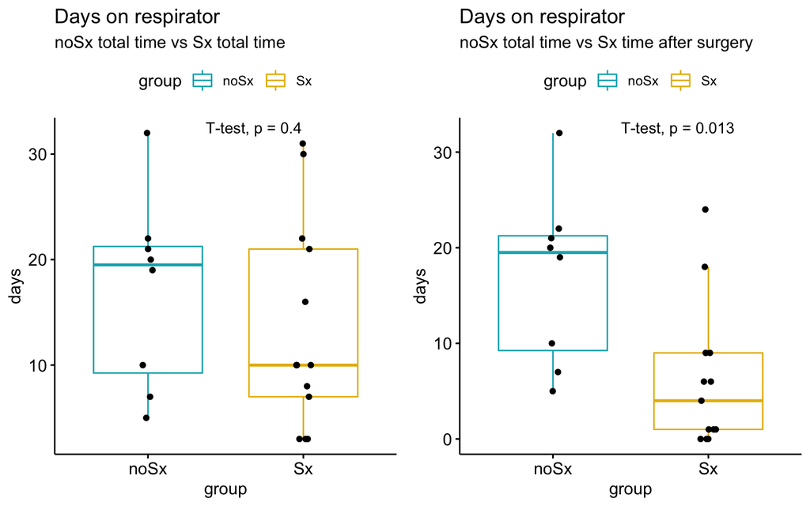

### Secondary endpoints: Overrepresentation test of tracheotomies, pneumonia, neurological deterioration and death

The cohort includes 23 individuals.  
All tested variables show now dependence from the group (Sx or noSx).

```
## Tracheotomies are not significantly overrepresented in any of the two groups
```

```
##       Tracheotomy
## group  0 1
##   noSx 4 6
##   Sx   4 9
```

```
##
##  Fisher's Exact Test for Count Data
##
## data:  t.trach
## p-value = 0.685
## alternative hypothesis: true odds ratio is not equal to 1
## 95 percent confidence interval:
##   0.1903082 11.6801267
## sample estimates:
## odds ratio
##   1.473407
```

```
## Pneumonia is not significantly overrepresented in any of the two groups
```

```
##       Pneumonia
## group  0 1
##   noSx 4 6
##   Sx   8 5
```

```
##
##  Fisher's Exact Test for Count Data
##
## data:  t.pneu
## p-value = 0.4136
## alternative hypothesis: true odds ratio is not equal to 1
## 95 percent confidence interval:
##  0.05577309 2.96978148
## sample estimates:
## odds ratio
##  0.4333803
```

```
## Neurological complications are not significantly overrepresented in any
##     of the two groups?
```

```
##       Neurology
## group  0 1
##   noSx 5 5
##   Sx   7 6
```

```
##
##  Fisher's Exact Test for Count Data
##
## data:  t.neu
## p-value = 1
## alternative hypothesis: true odds ratio is not equal to 1
## 95 percent confidence interval:
##  0.1229238 5.9705468
## sample estimates:
## odds ratio
##  0.8629176
```

```
## Deceased patients are not significantly overrepresented in any of the two groups
```

```
##       Death
## group   0  1
##   noSx  8  2
##   Sx   13  0
```

```
##
##  Fisher's Exact Test for Count Data
##
## data:  t.death
## p-value = 0.1779
## alternative hypothesis: true odds ratio is not equal to 1
## 95 percent confidence interval:
##  0.000000 3.982699
## sample estimates:
## odds ratio
##          0
```

## Linear regression analysis of both group as one cohort

Approach: use linear models combined with backward variable selection and likelihood ratio tests to reduce model complexity and identify predictors that have an influence on the response variable ‘Respirator.time’ (= total time on respirator starting from admission to ICU for both groups) and ‘newtime’ (time on respirator after the surgery for the Sx group), respectively.

The cohort includes 21 individuals (deceased patients excluded).

#### Linear model, data from both groups, y = total respiratory time

```
##
## Call:
## lm(formula = Respirator.time ~ group + age + GCS + female + Tracheotomy +
##     frac.Sternum + Lung.contusion + Pneumonia + Neurology, data = dat.t[dat.t$Death !=
##     "1", ])
##
## Residuals:
##    Min     1Q Median     3Q    Max
## -9.910 -3.843 -1.726  2.141 13.711
##
## Coefficients:
##                 Estimate Std. Error t value Pr(>|t|)
## (Intercept)     -17.8079    28.1388  -0.633   0.5398
## groupSx          -4.5846     4.5298  -1.012   0.3332
## age               0.1768     0.2787   0.635   0.5387
## GCS               0.8398     1.3576   0.619   0.5488
## femaleyes        -4.0607     7.2375  -0.561   0.5860
## Tracheotomy1     14.1749     5.1576   2.748   0.0189 *
## frac.Sternum1     3.2560     5.0924   0.639   0.5357
## Lung.contusion1   7.6988     6.1948   1.243   0.2398
## Pneumonia1        0.1070     4.7737   0.022   0.9825
## Neurology1       -0.5047     4.3132  -0.117   0.9090
## ---
## Signif. codes:  0 '***' 0.001 '**' 0.01 '*' 0.05 '.' 0.1 ' ' 1
##
## Residual standard error: 7.937 on 11 degrees of freedom
## Multiple R-squared:  0.6128, Adjusted R-squared:  0.2961
## F-statistic: 1.935 on 9 and 11 DF,  p-value: 0.1501
```

```
## Start:  AIC=93.42
## Respirator.time ~ group + age + GCS + female + Tracheotomy +
##     frac.Sternum + Lung.contusion + Pneumonia + Neurology
##
##                  Df Sum of Sq     RSS     AIC
## - Pneumonia       1      0.03  692.96  91.426
## - Neurology       1      0.86  693.79  91.451
## - female          1     19.83  712.76  92.017
## - GCS             1     24.10  717.03  92.143
## - age             1     25.37  718.30  92.180
## - frac.Sternum    1     25.75  718.68  92.191
## - group           1     64.53  757.46  93.294
## <none>                         692.93  93.425
## - Lung.contusion  1     97.29  790.22  94.184
## - Tracheotomy     1    475.81 1168.74 102.402
##
## Step:  AIC=91.43
## Respirator.time ~ group + age + GCS + female + Tracheotomy +
##     frac.Sternum + Lung.contusion + Neurology
##
##                  Df Sum of Sq     RSS     AIC
## - Neurology       1      0.85  693.82  89.451
## - GCS             1     24.07  717.03  90.143
## - female          1     24.23  717.19  90.147
## - age             1     26.51  719.47  90.214
## - frac.Sternum    1     28.15  721.12  90.262
## <none>                         692.96  91.426
## - group           1     71.10  764.06  91.477
## - Lung.contusion  1    147.69  840.65  93.483
## - Tracheotomy     1    511.71 1204.67 101.038
##
## Step:  AIC=89.45
## Respirator.time ~ group + age + GCS + female + Tracheotomy +
##     frac.Sternum + Lung.contusion
##
##                  Df Sum of Sq     RSS    AIC
## - female          1     24.27  718.08 88.173
## - age             1     27.24  721.05 88.260
## - frac.Sternum    1     29.49  723.30 88.325
## - GCS             1     32.77  726.59 88.421
```

[output cut: 41 more lines]

```
## Respirator.time ~ group + Tracheotomy + Lung.contusion
##
##                  Df Sum of Sq     RSS    AIC
## - group           1     71.79  846.72 83.634
## <none>                         774.93 83.773
## - Lung.contusion  1    103.65  878.58 84.409
## - Tracheotomy     1    543.43 1318.36 92.932
##
## Step:  AIC=83.63
## Respirator.time ~ Tracheotomy + Lung.contusion
##
##                  Df Sum of Sq     RSS    AIC
## <none>                         846.72 83.634
## - Lung.contusion  1    213.86 1060.58 86.363
## - Tracheotomy     1    473.51 1320.22 90.962
```

```
##
## Call:
## lm(formula = Respirator.time ~ Tracheotomy + Lung.contusion,
##     data = dat.t[dat.t$Death != "1", ])
##
## Residuals:
##     Min      1Q  Median      3Q     Max
## -12.488  -2.569  -1.488   3.236  15.236
##
## Coefficients:
##                 Estimate Std. Error t value Pr(>|t|)
## (Intercept)        5.569      2.550   2.184  0.04243 *
## Tracheotomy1      10.195      3.213   3.173  0.00527 **
## Lung.contusion1    6.724      3.153   2.132  0.04702 *
## ---
## Signif. codes:  0 '***' 0.001 '**' 0.01 '*' 0.05 '.' 0.1 ' ' 1
##
## Residual standard error: 6.859 on 18 degrees of freedom
## Multiple R-squared:  0.5269, Adjusted R-squared:  0.4744
## F-statistic: 10.02 on 2 and 18 DF,  p-value: 0.001187
```

```
## Likelihood ratio test
##
## Model 1: Respirator.time ~ group + age + GCS + female + Tracheotomy +
##     frac.Sternum + Lung.contusion + Pneumonia + Neurology
## Model 2: Respirator.time ~ Tracheotomy + Lung.contusion
##   #Df  LogLik Df  Chisq Pr(>Chisq)
## 1  11 -66.510
## 2   4 -68.615 -7 4.2091     0.7554
```

```
##                      2.5 %   97.5 %
## (Intercept)     0.21219592 10.92602
## Tracheotomy1    3.44406530 16.94618
## Lung.contusion1 0.09871969 13.34843
```

```
## Residual plots of the reduced model
```

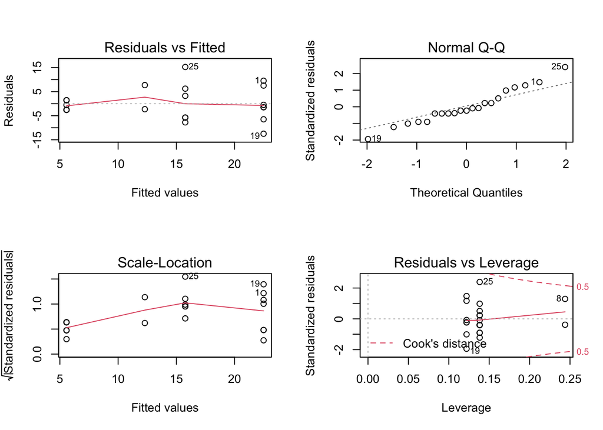

#### Linear model, data from both groups, y = time after surgery for the Sx group and total respiratory time for noSx group

```
##
## Call:
## lm(formula = newtime ~ group + age + GCS + female + Tracheotomy +
##     frac.Sternum + Lung.contusion + Pneumonia + Neurology, data = dat.t[dat.t$Death !=
##     "1", ])
##
## Residuals:
##     Min      1Q  Median      3Q     Max
## -6.2891 -3.3871 -0.6426  2.7639  8.8571
##
## Coefficients:
##                 Estimate Std. Error t value Pr(>|t|)
## (Intercept)      -6.7741    20.5423  -0.330   0.7478
## groupSx          -7.7740     3.3069  -2.351   0.0384 *
## age               0.1813     0.2034   0.891   0.3920
## GCS              -0.1664     0.9911  -0.168   0.8697
## femaleyes        -8.5640     5.2837  -1.621   0.1333
## Tracheotomy1      8.5313     3.7653   2.266   0.0446 *
## frac.Sternum1     5.2079     3.7176   1.401   0.1888
## Lung.contusion1  11.1489     4.5224   2.465   0.0314 *
## Pneumonia1       -0.8662     3.4850  -0.249   0.8083
## Neurology1        1.2261     3.1488   0.389   0.7044
## ---
## Signif. codes:  0 '***' 0.001 '**' 0.01 '*' 0.05 '.' 0.1 ' ' 1
##
## Residual standard error: 5.794 on 11 degrees of freedom
## Multiple R-squared:  0.7988, Adjusted R-squared:  0.6342
## F-statistic: 4.854 on 9 and 11 DF,  p-value: 0.008371
```

```
## Start:  AIC=80.21
## newtime ~ group + age + GCS + female + Tracheotomy + frac.Sternum +
##     Lung.contusion + Pneumonia + Neurology
##
##                  Df Sum of Sq    RSS    AIC
## - GCS             1     0.946 370.25 78.263
## - Pneumonia       1     2.074 371.37 78.326
## - Neurology       1     5.090 374.39 78.496
## - age             1    26.650 395.95 79.672
## <none>                        369.30 80.209
## - frac.Sternum    1    65.884 435.18 81.656
## - female          1    88.200 457.50 82.706
## - Tracheotomy     1   172.357 541.66 86.252
## - group           1   185.537 554.84 86.757
## - Lung.contusion  1   204.036 573.34 87.446
##
## Step:  AIC=78.26
## newtime ~ group + age + female + Tracheotomy + frac.Sternum +
##     Lung.contusion + Pneumonia + Neurology
##
##                  Df Sum of Sq    RSS    AIC
## - Pneumonia       1     1.987 372.23 76.375
## - Neurology       1     7.748 377.99 76.697
## - age             1    25.803 396.05 77.677
## <none>                        370.25 78.263
## - frac.Sternum    1    77.016 447.26 80.231
## - female          1    88.202 458.45 80.750
## - group           1   190.493 560.74 84.979
## - Lung.contusion  1   214.585 584.83 85.863
## - Tracheotomy     1   242.755 613.00 86.851
##
## Step:  AIC=76.37
## newtime ~ group + age + female + Tracheotomy + frac.Sternum +
##     Lung.contusion + Neurology
##
##                  Df Sum of Sq    RSS    AIC
## - Neurology       1     5.895 378.13 74.705
## - age             1    24.105 396.34 75.693
## <none>                        372.23 76.375
## - frac.Sternum    1    76.287 448.52 78.290
```

[output cut: 13 more lines]

```
## - female          1     92.53 470.66 77.302
## - group           1    250.27 628.39 83.372
## - Lung.contusion  1    285.28 663.41 84.510
## - Tracheotomy     1    334.51 712.64 86.014
##
## Step:  AIC=73.87
## newtime ~ group + female + Tracheotomy + frac.Sternum + Lung.contusion
##
##                  Df Sum of Sq    RSS    AIC
## <none>                        399.70 73.870
## - frac.Sternum    1     55.62 455.32 74.606
## - female          1     73.98 473.68 75.436
## - group           1    242.45 642.15 81.826
## - Lung.contusion  1    286.60 686.30 83.223
## - Tracheotomy     1    322.54 722.24 84.295
```

```
##
## Call:
## lm(formula = newtime ~ group + female + Tracheotomy + frac.Sternum +
##     Lung.contusion, data = dat.t[dat.t$Death != "1", ])
##
## Residuals:
##     Min      1Q  Median      3Q     Max
## -7.1325 -3.1632 -0.2005  1.5746  9.5332
##
## Coefficients:
##                 Estimate Std. Error t value Pr(>|t|)
## (Intercept)        4.430      3.521   1.258  0.22760
## groupSx           -8.194      2.717  -3.016  0.00868 **
## femaleyes         -6.849      4.111  -1.666  0.11641
## Tracheotomy1       9.262      2.662   3.479  0.00336 **
## frac.Sternum1      3.734      2.584   1.445  0.16908
## Lung.contusion1    8.969      2.735   3.280  0.00507 **
## ---
## Signif. codes:  0 '***' 0.001 '**' 0.01 '*' 0.05 '.' 0.1 ' ' 1
##
## Residual standard error: 5.162 on 15 degrees of freedom
## Multiple R-squared:  0.7823, Adjusted R-squared:  0.7097
## F-statistic: 10.78 on 5 and 15 DF,  p-value: 0.0001529
```

```
## Fine tuning: remove variables with p > 0.05
```

```
##
## Call:
## lm(formula = newtime ~ group + Tracheotomy + Lung.contusion,
##     data = dat.t[dat.t$Death != "1", ])
##
## Residuals:
##      Min       1Q   Median       3Q      Max
## -12.5663  -2.6054  -0.1466   2.8143  10.4337
##
## Coefficients:
##                 Estimate Std. Error t value Pr(>|t|)
## (Intercept)        8.540      2.617   3.264  0.00457 **
## groupSx          -10.039      2.733  -3.674  0.00188 **
## Tracheotomy1       7.646      2.708   2.824  0.01170 *
## Lung.contusion1    7.420      2.744   2.704  0.01505 *
## ---
## Signif. codes:  0 '***' 0.001 '**' 0.01 '*' 0.05 '.' 0.1 ' ' 1
##
## Residual standard error: 5.499 on 17 degrees of freedom
## Multiple R-squared:   0.72,  Adjusted R-squared:  0.6706
## F-statistic: 14.57 on 3 and 17 DF,  p-value: 5.942e-05
```

```
## Likelihood ratio test
##
## Model 1: newtime ~ group + female + Tracheotomy + frac.Sternum + Lung.contusion
## Model 2: newtime ~ group + Tracheotomy + Lung.contusion
##   #Df  LogLik Df  Chisq Pr(>Chisq)
## 1   7 -60.733
## 2   5 -63.375 -2 5.2837    0.07123 .
## ---
## Signif. codes:  0 '***' 0.001 '**' 0.01 '*' 0.05 '.' 0.1 ' ' 1
```

```
##                      2.5 %    97.5 %
## (Intercept)       3.019309 14.060009
## groupSx         -15.804974 -4.273339
## Tracheotomy1      1.933246 13.358922
## Lung.contusion1   1.630470 13.208887
```

```
## Residual plots of the reduced model
```

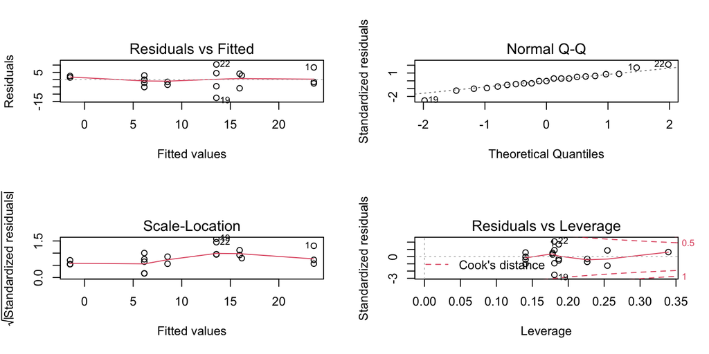

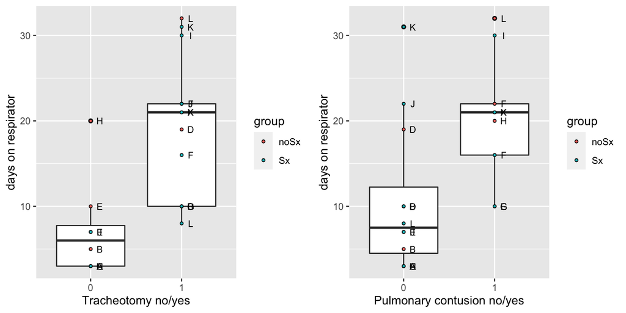

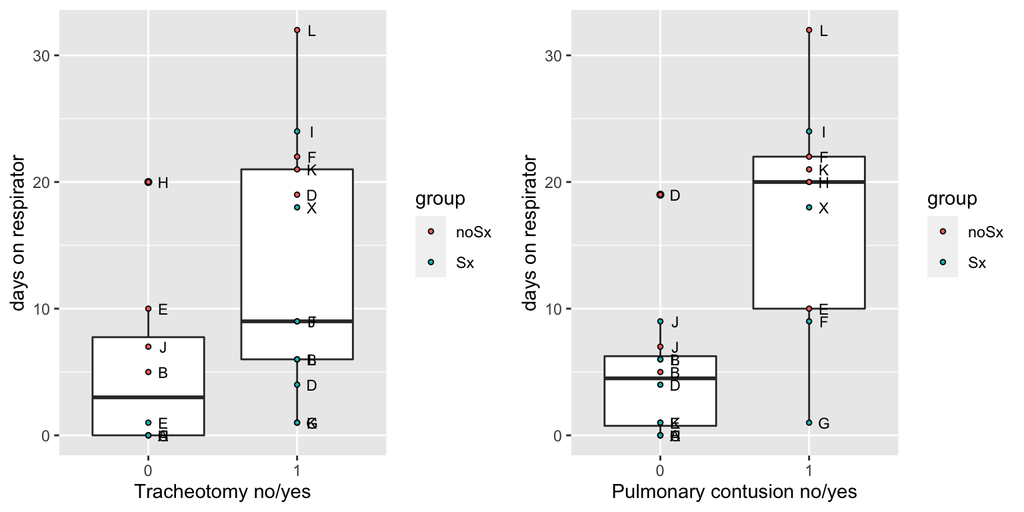

## Linear regression analysis of groups individually

Approach: For each group (Sx or noSx) try to find variables that have nn influence on the time on the respirator in order to identify possible markers for a good or a poor course of disease.

NOTE: due to the small number of observations these results have to be interpreted with caution.

### Data from noSx group only, y = total time

The noSx group consists of only 8 individuals when deceased patients are excluded. This limits the number of parameters that we can estimate significantly.

```
##
## Call:
## lm(formula = Respirator.time ~ Tracheotomy + frac.Sternum + Lung.contusion +
##     Pneumonia, data = d.nSx.ndec)
##
## Residuals:
##         1         2         3         4         8         9        10        12
##  4.80e+00 -5.20e+00  4.00e-01 -4.80e+00  5.20e+00 -1.11e-15 -1.20e+00  8.00e-01
##
## Coefficients:
##                   Estimate Std. Error t value Pr(>|t|)
## (Intercept)      6.200e+00  6.913e+00   0.897   0.4359
## Tracheotomy1     1.240e+01  4.525e+00   2.740   0.0713 .
## frac.Sternum1   -1.175e-15  5.842e+00   0.000   1.0000
## Lung.contusion1  2.400e+00  9.421e+00   0.255   0.8154
## Pneumonia1       6.200e+00  7.505e+00   0.826   0.4693
## ---
## Signif. codes:  0 '***' 0.001 '**' 0.01 '*' 0.05 '.' 0.1 ' ' 1
##
## Residual standard error: 5.842 on 3 degrees of freedom
## Multiple R-squared:  0.821,  Adjusted R-squared:  0.5823
## F-statistic: 3.439 on 4 and 3 DF,  p-value: 0.169
```

```
## Start:  AIC=30.4
## Respirator.time ~ Tracheotomy + frac.Sternum + Lung.contusion +
##     Pneumonia
##
##                  Df Sum of Sq    RSS    AIC
## - frac.Sternum    1     0.000 102.40 28.396
## - Lung.contusion  1     2.215 104.62 28.567
## - Pneumonia       1    23.297 125.70 30.035
## <none>                        102.40 30.396
## - Tracheotomy     1   256.267 358.67 38.424
##
## Step:  AIC=28.4
## Respirator.time ~ Tracheotomy + Lung.contusion + Pneumonia
##
##                  Df Sum of Sq    RSS    AIC
## - Lung.contusion  1     3.600 106.00 26.672
## - Pneumonia       1    27.457 129.86 28.296
## <none>                        102.40 28.396
## - Tracheotomy     1   256.267 358.67 36.424
##
## Step:  AIC=26.67
## Respirator.time ~ Tracheotomy + Pneumonia
##
##               Df Sum of Sq RSS    AIC
## <none>                     106 26.672
## - Pneumonia    1       128 234 31.007
## - Tracheotomy  1       338 444 36.131
```

```
##
## Call:
## lm(formula = Respirator.time ~ Tracheotomy + Pneumonia, data = d.nSx.ndec)
##
## Residuals:
##    1    2    3    4    8    9   10   12
##  4.5 -5.5 -0.5 -4.5  5.5  1.5 -1.5  0.5
##
## Coefficients:
##              Estimate Std. Error t value Pr(>|t|)
## (Intercept)     6.500      2.820   2.305   0.0693 .
## Tracheotomy1   13.000      3.256   3.993   0.0104 *
## Pneumonia1      8.000      3.256   2.457   0.0574 .
## ---
## Signif. codes:  0 '***' 0.001 '**' 0.01 '*' 0.05 '.' 0.1 ' ' 1
##
## Residual standard error: 4.604 on 5 degrees of freedom
## Multiple R-squared:  0.8147, Adjusted R-squared:  0.7406
## F-statistic: 10.99 on 2 and 5 DF,  p-value: 0.01478
```

```
## Fine tuning: remove variables with p > 0.05
```

```
##
## Call:
## lm(formula = Respirator.time ~ Tracheotomy, data = d.nSx.ndec)
##
## Residuals:
##    Min     1Q Median     3Q    Max
##  -5.50  -3.75  -2.00   1.75   9.50
##
## Coefficients:
##              Estimate Std. Error t value Pr(>|t|)
## (Intercept)    10.500      3.122   3.363   0.0152 *
## Tracheotomy1   13.000      4.416   2.944   0.0258 *
## ---
## Signif. codes:  0 '***' 0.001 '**' 0.01 '*' 0.05 '.' 0.1 ' ' 1
##
## Residual standard error: 6.245 on 6 degrees of freedom
## Multiple R-squared:  0.5909, Adjusted R-squared:  0.5227
## F-statistic: 8.667 on 1 and 6 DF,  p-value: 0.02582
```

```
## Likelihood ratio test
##
## Model 1: Respirator.time ~ Tracheotomy + frac.Sternum + Lung.contusion +
##     Pneumonia
## Model 2: Respirator.time ~ Tracheotomy
##   #Df  LogLik Df  Chisq Pr(>Chisq)
## 1   6 -21.549
## 2   3 -24.855 -3 6.6115    0.08537 .
## ---
## Signif. codes:  0 '***' 0.001 '**' 0.01 '*' 0.05 '.' 0.1 ' ' 1
```

```
##                2.5 %   97.5 %
## (Intercept)  2.85952 18.14048
## Tracheotomy1 2.19473 23.80527
```

```
## Residual plots of the reduced model
```

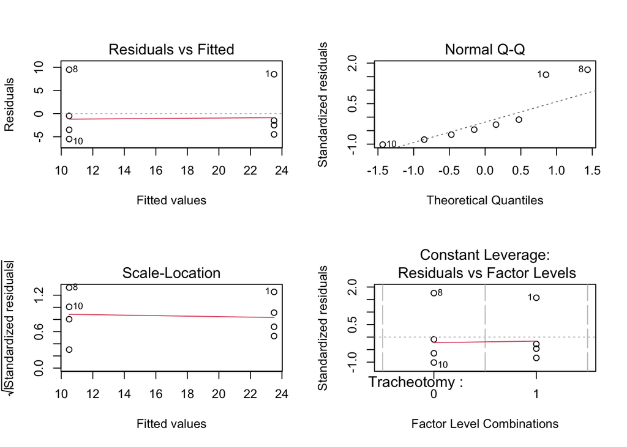

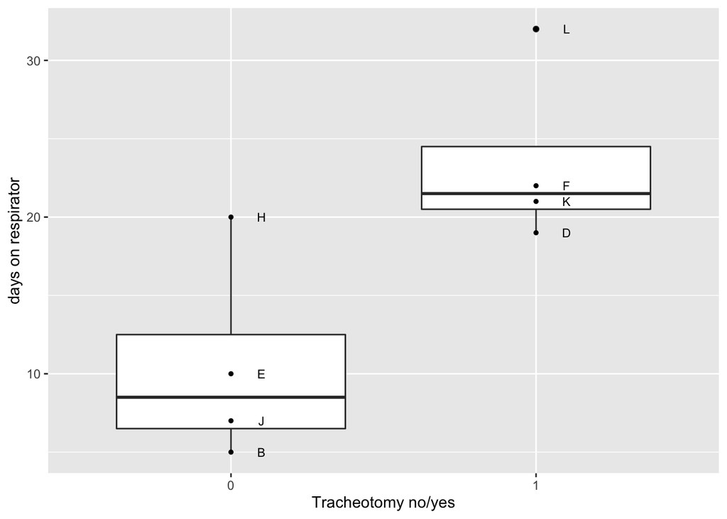

### Data from Sx group only, y = time after surgery (newtime)

The Sx group consists of 13 individuals when deceased patients are excluded.

```
##
## Call:
## lm(formula = newtime ~ age + GCS + female + Tracheotomy + frac.Sternum +
##     Lung.contusion + Pneumonia + Neurology, data = d.Sx.ndec)
##
## Residuals:
##     13     14     15     16     17     18     19     20     21     22     23
## -1.045  3.527 -2.493 -3.893 -1.104 -4.276 -5.199  4.642  2.898  6.577  5.199
##     24     25
## -3.455 -1.378
##
## Coefficients:
##                 Estimate Std. Error t value Pr(>|t|)
## (Intercept)      -55.289     61.497  -0.899    0.419
## age                0.265      0.407   0.651    0.551
## GCS                2.388      3.512   0.680    0.534
## femaleyes         -9.631      7.170  -1.343    0.250
## Tracheotomy1       2.513     10.077   0.249    0.815
## frac.Sternum1     10.844      8.890   1.220    0.290
## Lung.contusion1   16.105      9.076   1.774    0.151
## Pneumonia1        -7.543      7.734  -0.975    0.385
## Neurology1        10.555     12.927   0.817    0.460
##
## Residual standard error: 6.991 on 4 degrees of freedom
## Multiple R-squared:  0.7095, Adjusted R-squared:  0.1284
## F-statistic: 1.221 on 8 and 4 DF,  p-value: 0.4522
```

```
## Start:  AIC=53.24
## newtime ~ age + GCS + female + Tracheotomy + frac.Sternum + Lung.contusion +
##     Pneumonia + Neurology
##
##                  Df Sum of Sq    RSS    AIC
## - Tracheotomy     1     3.038 198.53 51.438
## - age             1    20.717 216.21 52.547
## - GCS             1    22.587 218.08 52.659
## <none>                        195.50 53.238
## - Neurology       1    32.584 228.08 53.242
## - Pneumonia       1    46.480 241.98 54.011
## - frac.Sternum    1    72.711 268.21 55.349
## - female          1    88.192 283.69 56.078
## - Lung.contusion  1   153.882 349.38 58.786
##
## Step:  AIC=51.44
## newtime ~ age + GCS + female + frac.Sternum + Lung.contusion +
##     Pneumonia + Neurology
##
##                  Df Sum of Sq    RSS    AIC
## - GCS             1     26.14 224.68 51.046
## <none>                        198.53 51.438
## - age             1     41.54 240.08 51.908
## - frac.Sternum    1     73.78 272.31 53.546
## - Neurology       1     86.48 285.02 54.139
## - female          1     92.78 291.32 54.423
## - Pneumonia       1     94.11 292.65 54.482
## - Lung.contusion  1    345.58 544.11 62.545
##
## Step:  AIC=51.05
## newtime ~ age + female + frac.Sternum + Lung.contusion + Pneumonia +
##     Neurology
##
##                  Df Sum of Sq    RSS    AIC
## <none>                        224.68 51.046
## - age             1     40.86 265.53 51.218
## - frac.Sternum    1     58.50 283.18 52.055
## - Pneumonia       1     67.99 292.67 52.483
## - female          1     89.85 314.53 53.420
## - Neurology       1    110.04 334.72 54.228
## - Lung.contusion  1    335.65 560.33 60.926
```

```
##
## Call:
## lm(formula = newtime ~ age + female + frac.Sternum + Lung.contusion +
##     Pneumonia + Neurology, data = d.Sx.ndec)
##
## Residuals:
##     Min      1Q  Median      3Q     Max
## -5.9620 -3.7216 -0.5559  1.6197  8.3247
##
## Coefficients:
##                 Estimate Std. Error t value Pr(>|t|)
## (Intercept)     -21.5057    21.8727  -0.983   0.3635
## age               0.3159     0.3024   1.045   0.3365
## femaleyes        -9.6611     6.2370  -1.549   0.1724
## frac.Sternum1     5.6093     4.4879   1.250   0.2579
## Lung.contusion1  15.3831     5.1382   2.994   0.0242 *
## Pneumonia1       -6.3314     4.6987  -1.347   0.2265
## Neurology1        6.4816     3.7811   1.714   0.1373
## ---
## Signif. codes:  0 '***' 0.001 '**' 0.01 '*' 0.05 '.' 0.1 ' ' 1
##
## Residual standard error: 6.119 on 6 degrees of freedom
## Multiple R-squared:  0.6661, Adjusted R-squared:  0.3322
## F-statistic: 1.995 on 6 and 6 DF,  p-value: 0.2107
```

```
## Likelihood ratio test
##
## Model 1: newtime ~ age + GCS + female + Tracheotomy + frac.Sternum + Lung.contusion +
##     Pneumonia + Neurology
## Model 2: newtime ~ age + female + frac.Sternum + Lung.contusion + Pneumonia +
##     Neurology
##   #Df  LogLik Df  Chisq Pr(>Chisq)
## 1  10 -36.065
## 2   8 -36.969 -2 1.8087     0.4048
```

```
##                      2.5 %    97.5 %
## (Intercept)     -75.026329 32.014910
## age              -0.424145  1.055969
## femaleyes       -24.922339  5.600235
## frac.Sternum1    -5.372202 16.590801
## Lung.contusion1   2.810466 27.955767
## Pneumonia1      -17.828608  5.165881
## Neurology1       -2.770422 15.733610
```

```
## Residual plots of the reduced model
```

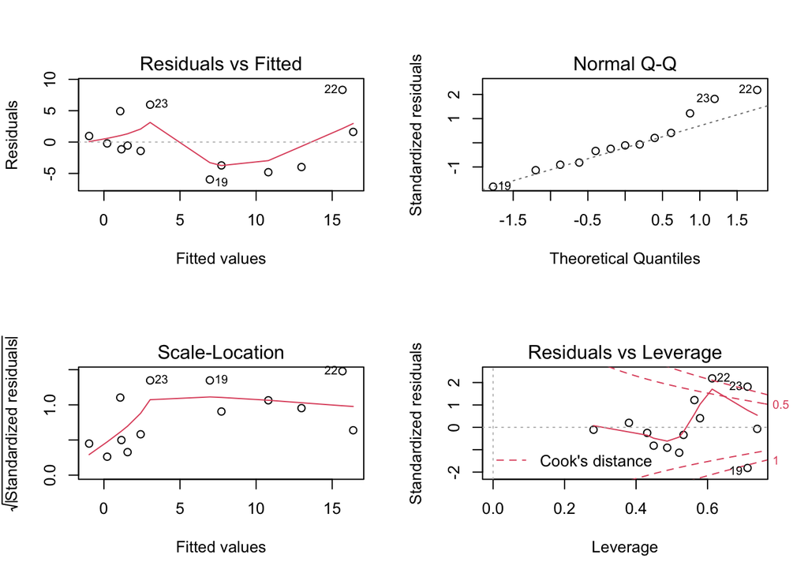

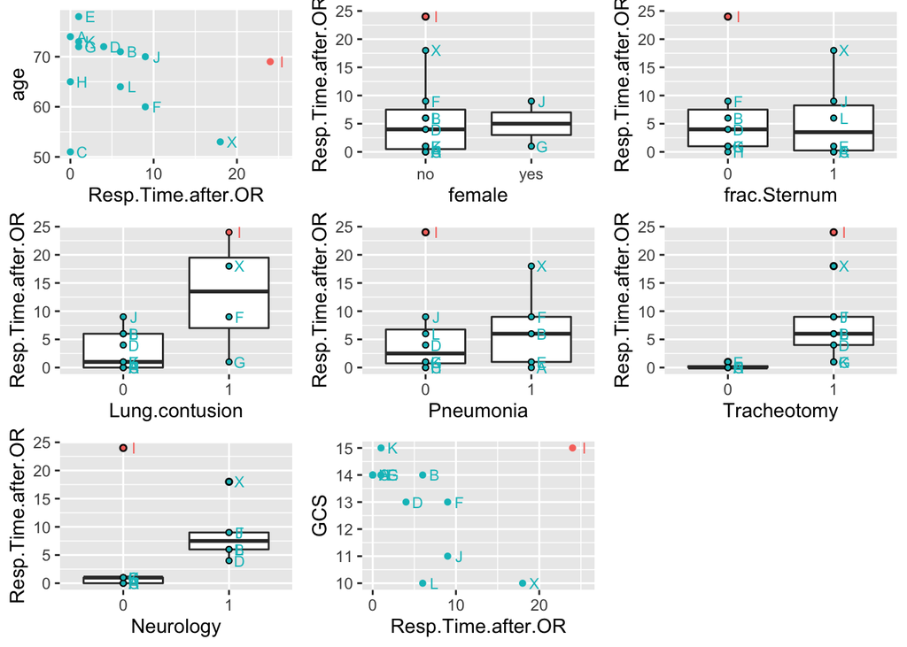

### Data from Sx group only, individual I excluded, y = time after surgery (newtime)

Patient I behaves differently than the rest of the Sx group: Patient I suffered from a lung contusion, spent the longest period of the entire group at the respirator (24 days) after surgery and received a tracheotomy, but had a GCS of 15 at admission to the hospital and no complications. Medical records revealed that this patient underwent a combined surgery (Rippenstabilisation und 3-fach Bypassoperation) and suffered from a ‘post-operativem Delir’ which was most probably induced by the long and complex surgery. The following analysis excludes patient I.

```
##
## Call:
## lm(formula = newtime ~ age + GCS + female + Tracheotomy + frac.Sternum +
##     Lung.contusion + Pneumonia + Neurology, data = d.Sx.noI)
##
## Residuals:
##      13      14      15      16      17      18      19      20      21      23
## -1.0955 -1.1811 -0.3447  1.4591  0.9484 -0.7697 -1.3282  0.4918  2.0979  1.3282
##      24      25
## -2.9343  1.3282
##
## Coefficients:
##                 Estimate Std. Error t value Pr(>|t|)
## (Intercept)      49.7126    34.3173   1.449    0.243
## age              -0.2610     0.2038  -1.280    0.290
## GCS              -2.3743     1.7875  -1.328    0.276
## femaleyes         2.6777     4.0110   0.668    0.552
## Tracheotomy1      4.6258     4.1772   1.107    0.349
## frac.Sternum1    -2.8174     4.7418  -0.594    0.594
## Lung.contusion1  -2.6566     5.5757  -0.476    0.666
## Pneumonia1        6.7535     4.4817   1.507    0.229
## Neurology1       -2.1405     6.0158  -0.356    0.746
##
## Residual standard error: 2.88 on 3 degrees of freedom
## Multiple R-squared:  0.9234, Adjusted R-squared:  0.7192
## F-statistic: 4.522 on 8 and 3 DF,  p-value: 0.1209
```

```
## Start:  AIC=26.75
## newtime ~ age + GCS + female + Tracheotomy + frac.Sternum + Lung.contusion +
##     Pneumonia + Neurology
##
##                  Df Sum of Sq    RSS    AIC
## - Neurology       1    1.0499 25.930 25.246
## - Lung.contusion  1    1.8828 26.763 25.625
## - frac.Sternum    1    2.9278 27.808 26.085
## - female          1    3.6962 28.577 26.412
## <none>                        24.880 26.750
## - Tracheotomy     1   10.1703 35.051 28.863
## - age             1   13.5951 38.476 29.981
## - GCS             1   14.6328 39.513 30.301
## - Pneumonia       1   18.8328 43.713 31.513
##
## Step:  AIC=25.25
## newtime ~ age + GCS + female + Tracheotomy + frac.Sternum + Lung.contusion +
##     Pneumonia
##
##                  Df Sum of Sq    RSS    AIC
## - Lung.contusion  1     0.838 26.769 23.628
## - frac.Sternum    1     1.943 27.873 24.113
## - female          1     2.689 28.620 24.430
## <none>                        25.930 25.246
## - Tracheotomy     1    10.924 36.855 27.465
## - age             1    14.821 40.751 28.671
## - GCS             1    27.163 53.093 31.846
## - Pneumonia       1    34.522 60.452 33.403
##
## Step:  AIC=23.63
## newtime ~ age + GCS + female + Tracheotomy + frac.Sternum + Pneumonia
##
##                Df Sum of Sq    RSS    AIC
## - frac.Sternum  1     1.234 28.002 22.169
## - female        1     1.893 28.662 22.448
## <none>                      26.769 23.628
## - Tracheotomy   1    10.541 37.310 25.612
## - age           1    18.746 45.515 27.998
## - GCS           1    26.433 53.202 29.870
## - Pneumonia     1    54.459 81.228 34.948
##
## Step:  AIC=22.17
## newtime ~ age + GCS + female + Tracheotomy + Pneumonia
##
##               Df Sum of Sq    RSS    AIC
## - female       1     1.310 29.312 20.717
## <none>                     28.002 22.169
## - age          1    19.981 47.983 26.631
## - Tracheotomy  1    40.009 68.011 30.817
## - GCS          1    45.524 73.526 31.753
## - Pneumonia    1    53.528 81.531 32.993
##
## Step:  AIC=20.72
## newtime ~ age + GCS + Tracheotomy + Pneumonia
##
##               Df Sum of Sq    RSS    AIC
## <none>                     29.312 20.717
## - age          1    18.741 48.054 24.649
## - Tracheotomy  1    44.757 74.069 29.841
## - GCS          1    49.598 78.910 30.601
## - Pneumonia    1    55.781 85.093 31.506
```

```
##
## Call:
## lm(formula = newtime ~ age + GCS + Tracheotomy + Pneumonia, data = d.Sx.noI)
##
## Residuals:
##     Min      1Q  Median      3Q     Max
## -3.4804 -0.8845 -0.0122  1.0469  2.1978
##
## Coefficients:
##              Estimate Std. Error t value Pr(>|t|)
## (Intercept)  31.41038    6.31680   4.973  0.00161 **
## age          -0.17283    0.08169  -2.116  0.07219 .
## GCS          -1.55652    0.45227  -3.442  0.01081 *
## Tracheotomy1  4.69620    1.43645   3.269  0.01369 *
## Pneumonia1    4.42065    1.21122   3.650  0.00818 **
## ---
## Signif. codes:  0 '***' 0.001 '**' 0.01 '*' 0.05 '.' 0.1 ' ' 1
##
## Residual standard error: 2.046 on 7 degrees of freedom
## Multiple R-squared:  0.9098, Adjusted R-squared:  0.8582
## F-statistic: 17.65 on 4 and 7 DF,  p-value: 0.0009228
```

```
## Fine tuning: remove variables with p > 0.05
```

```
##
## Call:
## lm(formula = newtime ~ GCS + Tracheotomy + Pneumonia, data = d.Sx.noI)
##
## Residuals:
##     Min      1Q  Median      3Q     Max
## -4.1393 -1.2148  0.2148  1.1120  3.5990
##
## Coefficients:
##              Estimate Std. Error t value Pr(>|t|)
## (Intercept)   26.0487     6.9299   3.759  0.00555 **
## GCS           -1.9950     0.4815  -4.144  0.00324 **
## Tracheotomy1   4.0403     1.6799   2.405  0.04283 *
## Pneumonia1     4.2617     1.4479   2.943  0.01861 *
## ---
## Signif. codes:  0 '***' 0.001 '**' 0.01 '*' 0.05 '.' 0.1 ' ' 1
##
## Residual standard error: 2.451 on 8 degrees of freedom
## Multiple R-squared:  0.8521, Adjusted R-squared:  0.7966
## F-statistic: 15.36 on 3 and 8 DF,  p-value: 0.001105
```

```
## Likelihood ratio test
##
## Model 1: newtime ~ age + GCS + female + Tracheotomy + frac.Sternum + Lung.contusion +
##     Pneumonia + Neurology
## Model 2: newtime ~ GCS + Tracheotomy + Pneumonia
##   #Df  LogLik Df  Chisq Pr(>Chisq)
## 1  10 -21.402
## 2   5 -25.352 -5 7.8989     0.1619
```

```
##                   2.5 %     97.5 %
## (Intercept)  10.0682893 42.0290261
## GCS          -3.1052125 -0.8847204
## Tracheotomy1  0.1664938  7.9140431
## Pneumonia1    0.9229711  7.6005188
```

```
## Residual plots of the reduced model
```

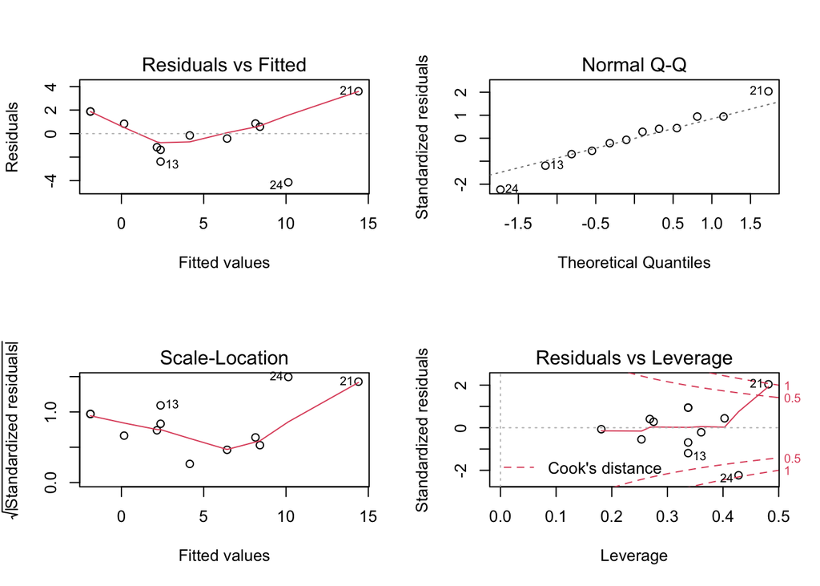

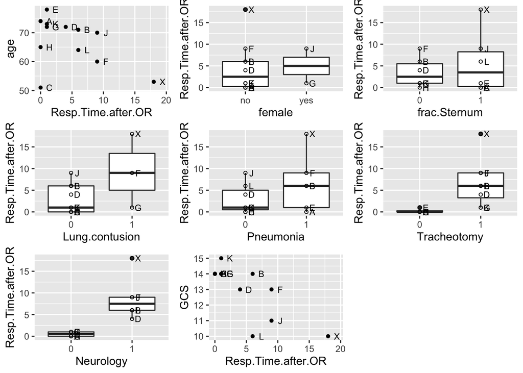